*This is a post version of the talk to be given for Pittsburgh useR meeting on Wednesday, Oct 15.*

## Overview

- forward-pipe operator `%>%` aka “then-do”
- underused `%in%` operator
- `Reduce` function
- `...` argument for functions
- `<<-` operator and scope
- writing custom binary operators

## Forward-pipe operator *%>%* aka “then-do”

The `magrittr` package adds a new operator to the R language and enables you to write cleaner code.

Traditionally, you write code inside-to-outside:

```r
h(f(x),y)
```

`%>%` lets you write a left-to-right pipeline:

```r
x %>% f %>% h(y) # Implict: h(<input>,y)
```

By default, the input is given to the function as the first argument. You can also specify the position of the input with `.`

```r
x %>% f %>% h(y,.)
```

## *%>%* Example

Nested functions are hard to read and can get hard to write:

```r
library(xtable) # Export tables to LaTeX or HTML
xtable(
    coef(
        summary(
            lm(sqrt(dist)~speed,cars)
            )
        )
    )
```

The “then-do” approach makes writing and reading easier:

```r
library(magrittr) # Provides pipe-forwarding mechanisms
cars %>% lm(sqrt(dist)~speed,.) %>% summary %>% coef %>% xtable
```

```r
library(knitr) # for kable() which renders tables to markdown
cars %>% lm(sqrt(dist)~.,.) %>% summary %>% coef
```

```
##             Estimate Std. Error t value  Pr(>|t|)
## (Intercept)   1.2771    0.48444   2.636 1.126e-02
## speed         0.3224    0.02978  10.825 1.773e-14
```

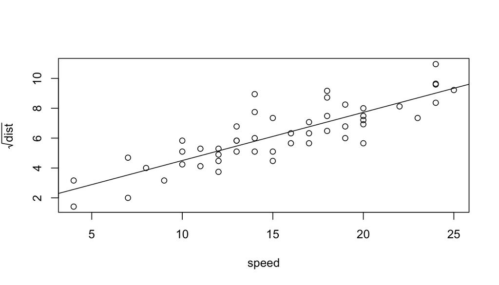

```r
cars %>%
    transform(dist=sqrt(dist)) %>%
    function(x) {
        x %>% plot(ylab=expression(sqrt(dist)))
        x %>% lm(dist~speed,.) %>% abline
        }
```

## %in% operator

`match` returns a vector of the positions of (first) matches of its first argument in its second:

```r
match(c("Shocktober","october","Rocktober","October","Inktober"),month.name)
```

```
## [1] NA NA NA 10 NA
```

As you can see, the 4th element (October) is the 10th element in the vector of month names. The binary operator `%in%` is a more intuitive interface to `match`:

```r
c("Shocktober","october","Rocktober","October","Inktober") %in% month.name
```

```
## [1] FALSE FALSE FALSE  TRUE FALSE
```

```r
c("Shocktober","october","Rocktober","October","Inktober") %in% month.name %>% which
```

```
## [1] 4
```

## *Reduce* function

```r
A <- month.name[2:6] # February, March, April, May, June
B <- month.name[4:10] # April, May, June, July, August, September, October
C <- month.name[3*(1:4)] # March, June, September, December
D <- month.name[2*(1:6)] # February, April, June, August, October, December
```

```r
intersect(intersect(intersect(A,B),C),D)
```

```
## [1] "June"
```

```r
# alt: intersect(A,B) %>% intersect(C) %>% intersect(D)
```

That looks like it can get super messy super fast if we start adding even more elements. Fortunately, `Reduce` uses a binary function to successively combine the elements of a given vector and a possibly given initial value.

```r
Reduce(intersect,list(A,B,C,D))
```

```
## [1] "June"
```

### Silly Application

*Royal Rumble* is a battle royal that begins with two participants in the ring, with the remaining participants introduced one by one (at a set time period). The winner is the last participant standing. Take a moment to read the pipe sequence and figure out what’s going on.

```r
library(babynames) # devtools::install_github("hadley/babynames")
library(dplyr) # A fast, consistent tool for working with data frame like objects.
top10 <- babynames %>% filter(year==1990) %>% top_n(10,n) %>% select(name) %>% sample
```

```
##  Contestant 1  Contestant 2  Contestant 3  Contestant 4  Contestant 5
##      "Daniel"    "Brittany"       "David"     "Michael" "Christopher"
##  Contestant 6  Contestant 7  Contestant 8  Contestant 9 Contestant 10
##      "Ashley"      "Amanda"      "Joshua"     "Matthew"     "Jessica"
```

**Answer**: first we take the table of names and subset by the year 1990, then we get the top 10 names with respect to `n` (number of births), then we only get the column that’s of interest to us, and finally we randomize the order. (The presented code is actually missing `%>% c %>% unlist %>%` between `select(name)` and `sample`.)

```r
fight <- function(x,y) sample(c(x,y),1,prob=c(2,1)/3)
Reduce(fight,top10)
```

```
## [1] "Ashley"
```

## Application of %in% and *Reduce* (Background)

Suppose we have patients’ visits to a clinic, with up to 5 diagnoses established per visit. Suppose a diagnosis is coded 001–100. (Although in reality they would be ICD-9 codes.)

|  | dx1 | dx2 | dx3 | dx4 | dx5 | age |
| --- | --- | --- | --- | --- | --- | --- |
| 995 | 057 | 068 | 051 | 052 | NA | 54 |
| 996 | 093 | 057 | 066 | NA | NA | 60 |
| 997 | 062 | 010 | 060 | 033 | NA | 67 |
| 998 | 034 | 067 | NA | NA | NA | 55 |
| 999 | 029 | NA | NA | NA | NA | 57 |
| 1000 | 049 | NA | NA | NA | NA | 57 |

## Application of %in% and *Reduce*

### Objective

We are interested in patients whose “primary” (first three) diagnoses are kidney-related (049–060).

### Solution

```r
dx.kidney <- sprintf("%03i",49:60) # "049" "050" ... "059" "060"
index <- Reduce("|", # 'or'
                list(visits$dx1 %in% dx.kidney,
                     visits$dx2 %in% dx.kidney,
                     visits$dx3 %in% dx.kidney)) %>% which
# visits$age[index] : age of patients with kidney-related primary dx
```

## Optional arguments using ‘…’

**Example**: `apply(X, MARGIN, FUN, ...)` where `...` are arguments that are passed on to the function `FUN`

```r
inventory <- function(ArkID,...) {
    args <- list(...) # required
    args %>% unlist %>% as.table %>% addmargins
    }
inventory(1,Noah=1,Cats=2,Dogs=2,Penguins=2,Dinosaurs=0)
```

```
##      Noah      Cats      Dogs  Penguins Dinosaurs       Sum
##         1         2         2         2         0         7
```

## Out-of-scope assignment

A variable can be defined in global or local scope. Variables created inside of a function are local to it and die when the function is done. The operators `<<-` and `->>` cause a search to made through parent environments for an existing definition of the variable being assigned, subverting scope.

```r
save.creatures <- function(...) {
    args <- list(...) # required
    # some code that actually saves the creatures
    creatures.saved.local <- args %>% unlist %>% as.table %>% sum
    creatures.saved.global <<- args %>% unlist %>% as.table %>% sum
    }
creatures.saved.local <- 0; creatures.saved.global <- 0
save.creatures(Cats=2,Dogs=2,Penguins=2,Dinosaurs=0,Snuggleupagus=1)
c(Local=creatures.saved.local,Global=creatures.saved.global)
```

```
##  Local Global
##      0      7
```

## Binary Operators (built-in and in magrittr)

| Operator | Description |
| --- | --- |
| +, -, *, /, ^ | basic arithmetic |
| x %% y | modulus (x mod y) |
| X %*% Y | matrix multiplication |
| <, <=, >, >=, ==, != | basic logical |
| !x, x \| y, x & y | NOT x, x OR y, x AND y |
| x %in% y | elements of x in y |
| x %>% f | apply function f to x |

### Writing Custom Binary Operator

```r
"%rowInMat%" <- function(x,y) {
    result <- logical(nrow(y))
    for ( i in 1:nrow(y) ) result[i] <- all(x == y[i,]); return(result)
    }
```

Suppose we have the following matrix `x`:

```
[,1] [,2] [,3] [,4] [,5]
[1,]    1    1    0    1    0
[2,]    0    1    1    0    0
[3,]    0    1    0    1    0
[4,]    1    1    1    1    0
[5,]    1    0    0    0    0
[6,]    0    0    1    1    1
```

```r
c(0,1,0,1,0) %rowInMat% x
```

```
## [1] FALSE FALSE  TRUE FALSE FALSE FALSE
```